# Exploration GoBike 2017

## by Frederick Yen

## Investigation Overview

This presentation will be exploring the user behavior differences between the subscribers and customers of Go Bike in 2017. The main factors include ride start/end time and duration.

## Dataset Overview

The dataset being used for exploration is the 2017 Ford GoBike trip data dataset. It contains 13 columns with 519,700 non-null entries. Each entry contains trip info such as duration (int), start/end time (object), bike/station ID (int), station lat/long (float), and more.

## Rush Hour

Subscribers use the bikes the most around rush hour while the customers have no outstanding peaks of usage throughout the day.

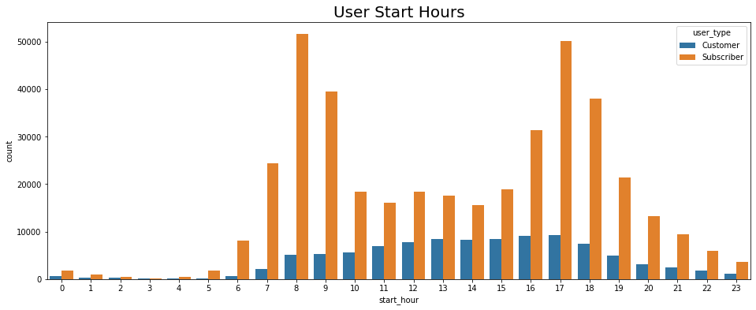

```python
fig, ax = plt.subplots(figsize=(16,6))
ax.set_title("User Start Hours",fontsize=20)
sb.countplot(data = trip_data_clean, x = 'start_hour', hue = 'user_type');
```

## Riding Every Month

Overall trend of number of rides through the months are similar when comparing subscribers to customers. Even though the number of rides for subscribers are 4~5 times more than the customers, most rides happened between September and November for both of the user groups.

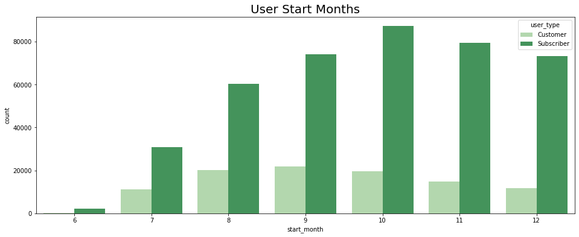

```python
fig, ax = plt.subplots(figsize=(16,6))
ax.set_title("User Start Months", fontsize=20)
sb.countplot(data = trip_data_clean, x = 'start_month', hue = 'user_type', palette = 'Greens');
```

## Day Rides

Customers have the longest rides when the bikes are checked out around noon. On the other hand, subscribers have a relative consistent ride duration through the whole day.

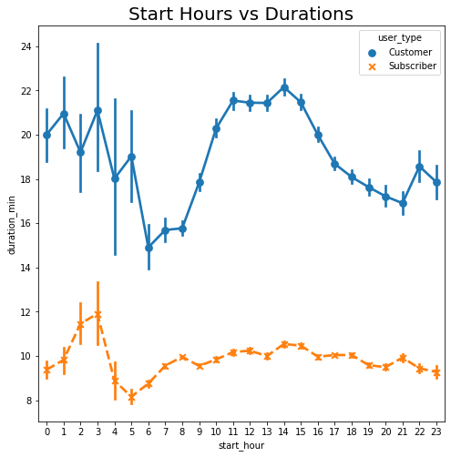

```python
fig, ax = plt.subplots(figsize = (8,8))
ax.set_title("Start Hours vs Durations", fontsize=20)
sb.pointplot(x="start_hour", y="duration_min", hue="user_type",
                   data=trip_data_clean,
                   markers=["o", "x"],
                   linestyles=["-", "--"]);
```